# Homework2 Code

Dani Antos

# Question 1

lambda=15 (mean) To set up the distribution, does it matter what “n” is? Should I just pick a big enough number to get a good distribution?

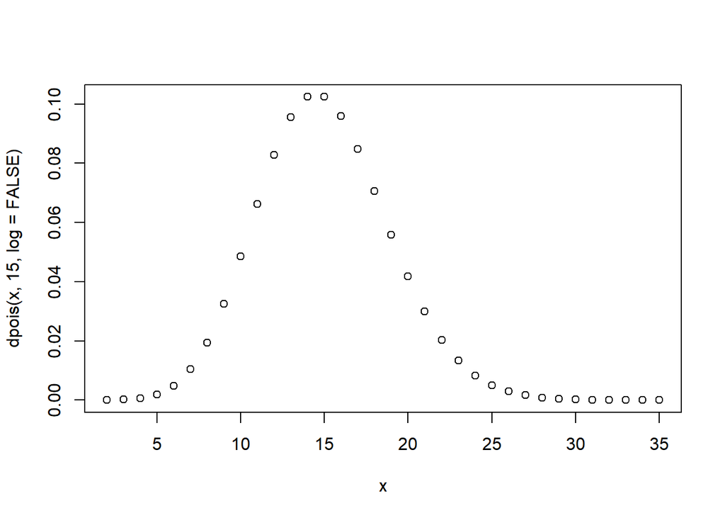

```r
set.seed(1)
x <- rpois(100000, 15)
plot(x, dpois(x, 15, log=FALSE))
```

Okay so probability that she’ll hear more than 8 calls…

ppois(x>=8, 15, lower.tail=TRUE, log.p=FALSE) I could do a sum but there’s no upper limit. (This code didn’t work at all so there’s no point in putting it in an R chunk)

or could I use qpois?

qpois(p, lambda, lower.tail=TRUE, log.p=FALSE)

```r
qpois(0.975, 15, lower.tail=TRUE, log.p=FALSE)
```

```
## [1] 23
```

```r
sum(ppois(8:23, 15, lower.tail=TRUE, log.p=FALSE))
```

```
## [1] 8.994475
```

Unsure, I got a number larger than 1, not sure if that can happen.

According to the textbook:

```r
1-ppois(q=8, lambda=15)
```

```
## [1] 0.9625535
```

BLESS MY SOUL I think I got it :’)

# Question 2

Probability of hearing no calls Before, I tried: p(x)= lambda^x*exp(-lambda)/x! but I got a number that was x10^-7

What if I do ppois again?

```r
ppois(0, 15, lower.tail=TRUE, log.p=FALSE)
```

```
## [1] 3.059023e-07
```

Update I got the same number as doing p(0) so maybe that’s the right answer…

According to the textbook:

```r
dpois(x=0,lambda=15)
```

```
## [1] 3.059023e-07
```

# Question 3

exactly 3 calls in a session, x=3, I know I can use that formula.

```r
p3 <- 15^3*exp(-15)/factorial(3)
p3
```

```
## [1] 0.0001720701
```

According to the textbook:

```r
dpois(x=3,lambda=15) #output is the same as the above formula
```

```
## [1] 0.0001720701
```

# Question 4

plot values in the range 0:30

y<- seq(0, 30, 0.0001) plot(y, dpois(y, 15, log=FALSE), cex=0.4)

Okay so now the x axis goes from 0-30 which is what I wanted, but there’s a black line near the bottom, not sure why it’s there, and it looks slightly like a normal distribution Also I’m getting warnings and I don’t know why/what that means…update, some of them are non-integers? Why would that be if log=FALSE?

plot(dpois(x=0:30,lambda=15),ylim=c(0,0.25),names.arg=0:30, ylab=“Pr(X=x)”, xlab=“x”)

Okay so it’s saying that I have non-graphical parameters but I’m getting a graph?

I’m going to just do a barplot like the book does instead of a scatter plot, because the histogram for the last question is also going to be a bar graph.

According to the textbook:

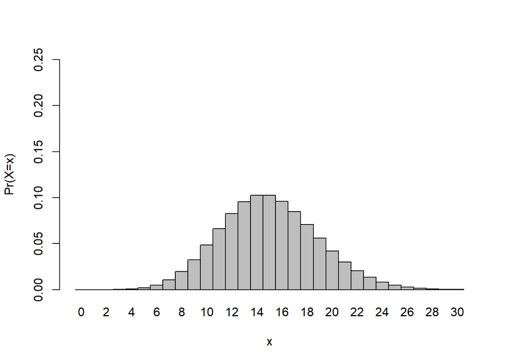

```r
barplot(dpois(x=0:30,lambda=15),ylim=c(0,0.25), space=0,names.arg=0:30, ylab="Pr(X=x)", xlab="x")
```

I didn’t get any warnings so I’m assuming this is good

# Question 5

simulate 104 results (2 years worth of work) so would n=104 or 1? Because you want one result per sample (not multiple numbers from the vector per sampling?)

Would the formula/code be the same for different types of distributions?

```r
set <- NULL
n<-1
for (i in 1:104){
set[i] <- mean(sample(x, n, replace=TRUE))
}
quantile(set)
```

```
##   0%  25%  50%  75% 100%
##    6   13   15   18   26
```

```r
quantile(set, c(0.025, 0.975))
```

```
##   2.5%  97.5%
##  9.000 23.425
```

I think I did it? Maybe without the quantile parts?

# Question 6

Honestly I’m totally winging it at this point

sooooo creating a histogram of the simulated results

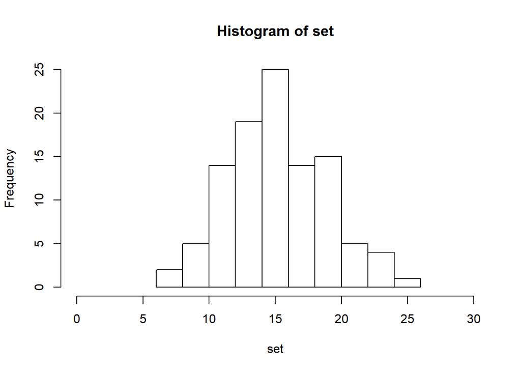

```r
hist(set, xlim=c(0,30))
```